# **Project 2**, APS1070 Winter 2023

**Anomaly Detection Algorithm using Gaussian Mixture Model**

**Deadline: Mar 4, 11 PM - 13 points**

**Academic Integrity**

This project is individual - it is to be completed on your own. If you have questions, please post your query in the APS1070 Piazza Q&A forums (the answer might be useful to others!).

Do not share your code with others, or post your work online. Do not submit code that you have not written yourself. Students suspected of plagiarism on a project, midterm or exam will be referred to the department for formal discipline for breaches of the Student Code of Conduct.

Please fill out the following:

- Name: **Abhishek Patel**
- Student Number: **1009311031**

### How to submit **(HTML + IPYNB)**

1. Download your notebook: `File -> Download .ipynb`
2. Click on the Files icon on the far left menu of Colab
3. Select & upload your `.ipynb` file you just downloaded, and then obtain its path (right click) (you might need to hit the Refresh button before your file shows up)
1. execute the following in a Colab cell:

   ```
   %%shell
   jupyter nbconvert --to html /PATH/TO/YOUR/NOTEBOOKFILE.ipynb
   ```

2. An HTML version of your notebook will appear in the files, so you can download it.
3. Submit **both** `HTML` and `IPYNB` files on Quercus for grading.

Ref: https://stackoverflow.com/a/64487858

## **Part 1: Getting started [2 Marks]**

We are going to work with a forest cover dataset: http://odds.cs.stonybrook.edu/forestcovercovertype-dataset/. This dataset contains 10 quantitative features that contain cartographic information.

- How many rows are there? **`There are 286048 rows.`** **[0.1]**
- Which column contains the targets? **`The 'Anomaly' column contains the Target values`** **[0.1]**
- What is the meaning of target values? **`0 = Non-Anomaly and 1 = Anomaly`** **[0.2]**

```python
# pip install wget
```

```python
# import wget

# wget.download('https://github.com/APS1070-W23/datasets/raw/main/forest_data_all.tar.gz','forest_data_all.tar.gz')
```

```python
# !tar -zxvf forest_data_all.tar.gz
```

```python
import pandas as pd
import numpy as np
import matplotlib.pyplot as plt
import seaborn as sns

# Splitting the data
from sklearn.model_selection import train_test_split

# Plotting the Histogram
import matplotlib.gridspec as gridspec

# For the GaussianMixture Model Training and Metric Calculation
from sklearn.mixture import GaussianMixture
from sklearn.metrics import roc_auc_score, recall_score, precision_score, f1_score
from sklearn.metrics import precision_recall_curve, auc, precision_recall_fscore_support

# To Display Tables in the middle of the code
from IPython import display as show

# Filter out warnings due to old versions
import warnings
warnings.filterwarnings('ignore')
```

```python
df = pd.read_csv('forest_data_all.csv')
df.head(10)
```

|  | Elevation | Aspect | Slope | Horizontal_Distance_To_Hydrology | Vertical_Distance_To_Hydrology | Horizontal_Distance_To_Roadways | Hillshade_9am | Hillshade_Noon | Hillshade_3pm | Horizontal_Distance_To_Fire_Points | Anomaly |
| --- | --- | --- | --- | --- | --- | --- | --- | --- | --- | --- | --- |
| 0 | 2804 | 139 | 9 | 268 | 65 | 3180 | 234 | 238 | 135 | 6121 | 0 |
| 1 | 2785 | 155 | 18 | 242 | 118 | 3090 | 238 | 238 | 122 | 6211 | 0 |
| 2 | 2579 | 132 | 6 | 300 | -15 | 67 | 230 | 237 | 140 | 6031 | 0 |
| 3 | 2886 | 151 | 11 | 371 | 26 | 5253 | 234 | 240 | 136 | 4051 | 0 |
| 4 | 2742 | 134 | 22 | 150 | 69 | 3215 | 248 | 224 | 92 | 6091 | 0 |
| 5 | 2880 | 209 | 17 | 216 | 30 | 4986 | 206 | 253 | 179 | 4323 | 0 |
| 6 | 2962 | 148 | 16 | 323 | 23 | 5916 | 240 | 236 | 120 | 3395 | 0 |
| 7 | 2811 | 135 | 1 | 212 | 30 | 3670 | 220 | 238 | 154 | 5643 | 0 |
| 8 | 2900 | 45 | 19 | 242 | 20 | 5199 | 221 | 195 | 100 | 4115 | 0 |
| 9 | 2570 | 346 | 2 | 0 | 0 | 331 | 215 | 235 | 158 | 5745 | 0 |

```python
# The shape defines the rows and columns of the dataframe
print(df.shape)

# This is to identify the target column. (Usually only has 2 values, either 0 or 1)
print(df.Anomaly.unique())
```

```
(286048, 11)
[0 1]
```

It's important to know how many examples we have for each class when we work with a new dataset.

- **What is the percentage of entries in the dataset for each class? ****[0.1]**

  ```
  0.96 % = Anomalous Data

  99.04% = Non-Anomalous Data
  ```

- **Is this data considered balanced or unbalanced? Why is this the case?** **[0.1]**

  ```
  The dataset is Unbalanced because there is a huge difference between the percentages of the Anomalous and
  Non-Anomalous data.
  If it were to be a Balanced dataset, the percentages would've been somewhat equal with a minor variance of ±2 %.
  ```

- **Why is balance/imbalance important? How might this class ditribution affect a KNN classifier for example, which we explored in Project 1?** **[0.5]**

  ```
  When a dataset is balanced, it means that the number of samples in each class is roughly the same. In this case, the model can learn to distinguish between the classes more easily because there are no biases towards any
  particular class. On the other hand, when a dataset is imbalanced, it means that the number of samples in each
  class is not equal, which can lead to several issues:

  Biased model: If one class has many more samples than the other, the model might become biased towards the
  majority class and struggle to classify samples from the minority class.

  Poor generalization: If the model is trained on an imbalanced dataset and evaluated on a balanced dataset, it
  might not generalize well because it was not exposed to enough examples from the minority class during training.

  Misleading evaluation metrics: If the dataset is imbalanced and the evaluation metric used is accuracy, the
  model might achieve high accuracy simply by predicting the majority class all the time, without actually
  learning to distinguish between the classes.

  In the case of a KNN classifier, the class distribution of the dataset can affect the classification performance in several ways. For example:

  When dealing with imbalanced datasets, KNN classifiers can face challenges such as unbalanced distances, where
  the distance between samples from the minority class might be larger than those from the majority class, making classification harder. Additionally, the neighborhood size can be biased towards the majority class, leading to misclassification of minority class samples. Hyperparameter tuning, such as adjusting the number of neighbors or the distance metric, may be necessary to achieve good performance on the minority class.
  ```

- **What metrics should we use to evaluate a model in such cases?** **[0.2]**

  ```
  The metrics that we would use to evaluate this model is F1 score and/or Recall. The higher the F-1 Score, the
  better the model.
  The F-1 score balances precision and recall on the True Positive class. For an unbalanced dataset, even if the
  model misclassifies a large number of the minor class into the major class, the precision rate is likely to be
  very high.
  The recall rate = TP/(TP+FN). Decreasing the number of FN (False Negatives (Misclassified data points)),
  will increase the recall rate and should probably increase the accuracy of classifiing the minor class
  correctly.
  ```

```python
total_rows = df.shape[0]
anomalous = (sum(df['Anomaly'] == 1)/total_rows)*100
non_anomalous = (sum(df['Anomaly'] == 0)/total_rows)*100

print(str(anomalous) + ' % is Anomalous Data out of the entire dataset.')
print(str(non_anomalous) + ' % is Non-Anomalous Data out of the entire dataset.')

if anomalous == non_anomalous:
    print('The dataset is Balanced.')
else:
    print('The dataset is Unbalanced.')
```

```
0.9603283365029646 % is Anomalous Data out of the entire dataset.
99.03967166349703 % is Non-Anomalous Data out of the entire dataset.
The dataset is Unbalanced.
```

Next, split the dataset into a training (65%), validation (20%) and testing set (15%). Set the random state to 40. **[0.2]**

Make sure to separate out the column corresponding to the targets.

```python
# Split the data

X = df.iloc[:,:-1]
y = df.iloc[:,-1]

X_train, X_val, X_test, y_train, y_val, y_test = 0, 0, 0, 0, 0, 0

# Splitting the train:test set ---> 85:15
X_train, X_test, y_train, y_test = train_test_split(X, y, test_size = 0.15, random_state = 40)

# Splitting the train:val set ---> 20:65
X_train, X_val, y_train, y_val = train_test_split(X_train, y_train, test_size = 0.2/0.85, random_state = 40)

print('Train set:', X_train.shape, y_train.shape)
print('Train set % = ', (X_train.shape[0]/(X_train.shape[0] + X_val.shape[0] + X_test.shape[0]))*100)
print('\nValidation set:', X_val.shape, y_val.shape)
print('Validation set % = ', (X_val.shape[0]/(X_train.shape[0] + X_val.shape[0] + X_test.shape[0]))*100)
print('\nTest set:', X_test.shape, y_test.shape)
print('Test set % = ', (X_test.shape[0]/(X_train.shape[0] + X_val.shape[0] + X_test.shape[0]))*100)
```

```
Train set: (185930, 10) (185930,)
Train set % =  64.9995804899877

Validation set: (57210, 10) (57210,)
Validation set % =  20.00013983667077

Test set: (42908, 10) (42908,)
Test set % =  15.000279673341538
```

Now, let's take a look at the difference in distribution for some variables between anomalous and non-anomalous forests:

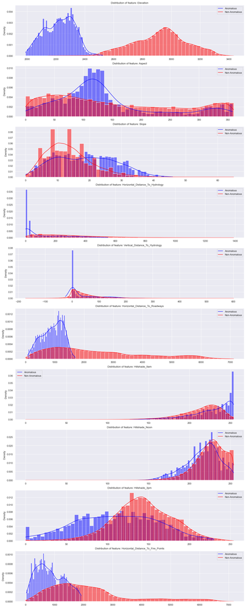

```python
theme = sns.set_theme(context='paper', style='darkgrid', palette='brg', font='sans-serif', font_scale=1, color_codes=True)
features=[f for f in df.columns if not 'id' in f and not 'Anomaly' in f]

nplots=np.size(features)
plt.figure(figsize=(15,4*nplots), dpi = 100)
gs = gridspec.GridSpec(nplots,1)
for i, feat in enumerate(features):
    ax = plt.subplot(gs[i])
    sns.histplot(X_train[feat][y_train==1], stat="density", kde=True, color="blue", bins=50)
    sns.histplot(X_train[feat][y_train==0], stat="density", kde=True, color="red", bins=50)
    ax.legend(['Anomalous', 'Non-Anomalous'],loc='best')
    ax.set_xlabel('')
    ax.set_title('Distribution of feature: ' + feat)
```

**Explain how these graphs could provide meaningful information about anomaly detection using a gaussian model. [0.5]**

The graphs show features from the dataset that follow different normal distibutions for the Anomalous and Non-Anomalous data points. The ones that are particularly seperate can be the features that can help in detecting the Anomalies better than the ones that aren't seperate. It can be done using 2 Gaussians with different variances for different features, helping detect the anomalies easier.

**The following features are good enough for seperating Anomalous data from Non-Anomalous data:**

- Elavation, Aspect, Horizontal_Distance_To_Hydrology,
- Horizontal_Distance_To_Roadways, Hillshade_3pm, Horizontal_Distance_To_Fire_Points

**The following features are not good enough for seperating Anomalous data from Non-Anomalous data:**

- Slope, Vertital_Distance_To_Hydrology, Hillshade_9am, Hillshade_Noon

## **Part 2: One Gaussian model with Single feature: [2 Marks]**

We'll start by making a prediction using **a single feature of our dataset at a time**.

Please note that we **only use `V` features** in our model.

**a. Fitting regardless of class:**

1. Fit a single Gaussian distribution on a single feature of **the full training dataset** (both classes) using `sklearn.mixture.GaussianMixture` when `n_components=1`.
2. Compute AUC (Area under the ROC Curve) based on `sklearn.mixture.GaussianMixture.score_samples` on both the full training set and validation set (including both classes).
3. Repeat the above steps for each of the features and present your findings in a table. **[0.3]**
4. Find the best 3 features to distinguish anomalous forests from non-anomalous forests based on the AUC of the validation set. **[0.2]**
5. Make a prediction based on a model's scores: If the `score_samples` is lower than a threshold, we consider that forest as an anomaly. Find an optimal threshold that maximizes the F1 Score of the validation set for each of those 3 features separately. (Do not check every possible value for threshold, come up with a faster way!) Compute F1 score using `sklearn.metrics.f1_score`. **[0.5]**
6. Report Precision, Recall and F1 score on both training and validation set in a table using the threshold you found in previous step.
7. Report the complexity of your method (Big O notation) for determining the optimal threshold.**[0.3]**

**b. Fitting based on class:**

1. Pick 3 features that had the best AUC in Part 2a.
2. repeat part 2a to compute AUC, F1 score, Precision and Recall when you fit a Gaussian **only on non-anomalous forests in the training set** in step 1 (instead of all the forests).
3. Compare your results from parts 2a and 2b in a table (for both training and validation set). **[0.2]**
4. Are these results different or similar? Why?**[0.3]**
5. How would class imbalance affect any classifier in general (apart from just a KNN)? **[0.2]**

```python
# Step 5 Functions - Defined before the main calling, to avoid recursivity.

# Find F1 Score for different Thresholds
def f1_score_by_threshold(x, y):

    # Setting the Threshold by the 1st Quantile with 300 steps.
    threshold = np.arange(np.min(x),
                          np.quantile(x,.25),
                          (np.quantile(x,.25) - np.min(x)) / 300) # Found by looking at the max validation accuracy (Tried with 100 - 500 steps)

    # List Comprehension for the "Prediction List"
    prediction = [[(lambda score, thr: 1 if (score < thr) else 0)(score, thr) for score in x] for thr in threshold]

    # Prediction 'y_pred' dataframe.
    dict_pred = {'Threshold': threshold, 'Prediction': prediction}
    df_pred = pd.DataFrame(dict_pred)

    # Calculate F1 Score & + to Dataframe
    f1_score_list = [f1_score(y, y_pred) for y_pred in df_pred['Prediction']]
    df_pred['F1 Score'] = f1_score_list

    # Return the new Dataframe with F1 Score, Predicted value and Threshold value respectively.
    return df_pred

# Best Threshold and Maximized F1 Score
def best_f1_score_and_threshold(df_pred):
    best = df_pred.loc[df_pred['F1 Score'].idxmax()]
    return best['Threshold'], best['Prediction'], best['F1 Score']

# Step 6 Functions

# Find Precision and Recall for the maximized F1 Score with it's corresponding Threshold
def precision_recall_f1_with_threshold(x, y, best_thr):

    # List Comprehension for the "Prediction List"
    pred = [(lambda score, thr: 1 if (score < thr) else 0)(score, best_thr) for score in x]

    # Return Precision and Recall with the Best Threshold and Maximised F1 Score.
    return precision_score(y, pred), recall_score(y, pred), f1_score(y, pred)
```

### Part 2.a.

```python
# Step 1 - 3

features = [f for f in df.columns if not 'id' in f and not 'Anomaly' in f]

# Lists for AUC outputs
AUC_train_single_feat_list = []
AUC_val_single_feat_list = []

for feature in features:

    # Gaussian model for single feature
    gm_single = GaussianMixture(n_components = 1, random_state = 0)

    # Fitting a single normal distribution on a single feature
    gm_single.fit(X_train[feature].values.reshape(-1, 1))

    # Find scores on Train set and Validation set
    train_score = gm_single.score_samples(X_train[feature].values.reshape(-1, 1))
    val_score = gm_single.score_samples(X_val[feature].values.reshape(-1, 1))

    # Find AUC on Train set and Validation set and add to Lists
    AUC_train_single_feat_list.append(roc_auc_score(y_train, -1 * train_score))
    AUC_val_single_feat_list.append(roc_auc_score(y_val, -1 * val_score))

# AUC Outputs as DataFrame
AUC_list = {'Train Set AUC': AUC_train_single_feat_list, 'Validation Set AUC': AUC_val_single_feat_list}
df_AUC = pd.DataFrame(AUC_list, index = df.columns[0:10])
print('AUC for Train and Validation Sets')
show.display(df_AUC)

# Step 4

# Top 3 Features based on Validation set AUC
max_feat_name = df_AUC.nlargest(3, 'Validation Set AUC')
print('Top 3 Features')
show.display(max_feat_name)
max_feat_name = max_feat_name.index

# Step 5 - 6

# Find thresholds that Maximize F1 score
best_threshold_list = []

# Lists for F1 score, Precision, & Recall for Validation Set
best_val_f1_score_list = []
best_val_precision_list = []
best_val_recall_list = []

# Lists for F1 score, Precision, & Recall for Train Set
best_train_f1_score_list = []
best_train_precision_list = []
best_train_recall_list = []

for feature in max_feat_name:

    # Gaussian model for single feature
    gm_single = GaussianMixture(n_components = 1, random_state = 0)

    # Fitting a single normal distribution on a single feature
    gm_single.fit(X_train[feature].values.reshape(-1, 1))

    # Finding the scores in Train and Validation set
    train_score = gm_single.score_samples(X_train[feature].values.reshape(-1, 1))
    val_score = gm_single.score_samples(X_val[feature].values.reshape(-1, 1))

    # Finding the F1 Score and respective Thresholds from Validation set only.
    df_thr_based_f1_pred = f1_score_by_threshold(val_score, y_val)

    # Threshold, Prediction and F1 Score when F1 Score is maximized
    best_threshold, best_pred, best_f1_val = best_f1_score_and_threshold(df_thr_based_f1_pred)

    # Appending Optimized Threshhold to List
    best_threshold_list.append(best_threshold)

    # Precision and Recall for Max F1 Scores and Best Thresholds for Train and Validation set
    best_train_precision, best_train_recall, best_train_f1_score = precision_recall_f1_with_threshold(train_score, y_train, best_threshold)
    best_val_precision, best_val_recall, best_val_f1_score = precision_recall_f1_with_threshold(val_score, y_val, best_threshold)

    # Train Set Lists
    best_train_f1_score_list.append(best_train_f1_score) # F1 Score
    best_train_precision_list.append(best_train_precision) # Precision
    best_train_recall_list.append(best_train_recall) # Recall

    # Validation Set Lists
    best_val_f1_score_list.append(best_f1_val) # F1 Score
    best_val_precision_list.append(best_val_precision) # Precision
    best_val_recall_list.append(best_val_recall) # Recall

# Best Threshold with corresponding F1 Scores
opt_thr = pd.DataFrame({'Best Threshold': best_threshold_list,
                        'Best F1': best_val_f1_score_list},
                       index = max_feat_name)
print('Best Thresholds and F1 scores from Validation set')
show.display(opt_thr)

# Best F1 Score, Precision, Recall and Thresholds for Train set
train_metrics = pd.DataFrame({'Best Threshold': best_threshold_list,
                              'Best Precision': best_train_precision_list,
                              'Best Recall': best_train_recall_list,
                              'Best F1': best_train_f1_score_list},
                             index = max_feat_name)
print('Best Thresholds and Metrics for Training Set')
show.display(train_metrics)

# Best F1 Score, Precision, Recall and Thresholds for Validation set
validation_metrics = pd.DataFrame({'Best Threshold': best_threshold_list,
                                   'Best Precision': best_val_precision_list,
                                   'Best Recall': best_val_recall_list,
                                   'Best F1': best_val_f1_score_list},
                                  index = max_feat_name)
print('Best Thresholds and Metrics for Validation Set')
show.display(validation_metrics)
```

```
AUC for Train and Validation Sets
```

|  | Train Set AUC | Validation Set AUC |
| --- | --- | --- |
| Elevation | 0.999356 | 0.999233 |
| Aspect | 0.378533 | 0.359701 |
| Slope | 0.645241 | 0.648384 |
| Horizontal_Distance_To_Hydrology | 0.655722 | 0.645416 |
| Vertical_Distance_To_Hydrology | 0.650023 | 0.638430 |
| Horizontal_Distance_To_Roadways | 0.611058 | 0.617096 |
| Hillshade_9am | 0.642710 | 0.627760 |
| Hillshade_Noon | 0.535050 | 0.547447 |
| Hillshade_3pm | 0.664752 | 0.650066 |
| Horizontal_Distance_To_Fire_Points | 0.673600 | 0.661755 |

```
Top 3 Features
```

|  | Train Set AUC | Validation Set AUC |
| --- | --- | --- |
| Elevation | 0.999356 | 0.999233 |
| Horizontal_Distance_To_Fire_Points | 0.673600 | 0.661755 |
| Hillshade_3pm | 0.664752 | 0.650066 |

```
Best Thresholds and F1 scores from Validation set
```

|  | Best Threshold | Best F1 |
| --- | --- | --- |
| Elevation | -9.902716 | 0.880200 |
| Horizontal_Distance_To_Fire_Points | -8.694427 | 0.031772 |
| Hillshade_3pm | -7.785557 | 0.095808 |

```
Best Thresholds and Metrics for Training Set
```

|  | Best Threshold | Best Precision | Best Recall | Best F1 |
| --- | --- | --- | --- | --- |
| Elevation | -9.902716 | 0.826341 | 0.952220 | 0.884826 |
| Horizontal_Distance_To_Fire_Points | -8.694427 | 0.017872 | 0.455874 | 0.034395 |
| Hillshade_3pm | -7.785557 | 0.078281 | 0.114671 | 0.093044 |

```
Best Thresholds and Metrics for Validation Set
```

|  | Best Threshold | Best Precision | Best Recall | Best F1 |
| --- | --- | --- | --- | --- |
| Elevation | -9.902716 | 0.815100 | 0.956600 | 0.880200 |
| Horizontal_Distance_To_Fire_Points | -8.694427 | 0.016520 | 0.414105 | 0.031772 |
| Hillshade_3pm | -7.785557 | 0.081737 | 0.115732 | 0.095808 |

**Report the complexity of your method (Big O notation) for determining the optimal threshold.[0.3]**

The time complexity of the given code depends on the complexity of the functions used. Here is the Big O notation for each of the functions:

*Defined Functions*

- f1_score_by_threshold: **O(n<sup>2</sup> + n)**
- best_f1_score_and_threshold: **O(n)**
- precision_recall_f1_with_threshold: **O(n)**

*Steps 1 - 3*

- Features for loop: **O(n)**
- Gaussian Models for loop: **O(n)**

*Step 4*

- nlargest (Sorting method): **O(nlogn)**

*Step 5 - 6*

- Features for loop for Models: **O(n)**
  - f1_score_by_threshold: **O(n^2 + n)**
  - best_f1_score_and_threshold: **O(n)**
  - precision_recall_f1_with_threshold: **O(n)**
  - precision_recall_f1_with_threshold: **O(n)**

Overall Model Complexity = **O(n<sup>2</sup>) + O(n) + O(n) + O(n) + O(n) + O(nlogon) + O(n)(O(n<sup>2</sup>) + O(n) + O(n) + O(n))**

Results ----> **O(n<sup>3</sup>) + 4.O(n<sup>2</sup>) + 4.O(n) + O(nlogn)**

Therefore, the overall time complexity of the given code is **O(n<sup>3</sup>)** because the most complex function used in the code is the combination of the **`for loop of 'Models with features'`** in which the **`'f1_score_by_threshold'`** is called. However, this is an upper bound and the actual time complexity may be lower, depending on the size of the data and the specific parameters used.

### Part 2.b.

```python
X_train_na = X_train[y_train==0]
y_train_na = y_train[y_train==0]

# Step 1 - 3

features = [f for f in df.columns if not 'id' in f and not 'Anomaly' in f]

# Lists for AUC outputs
AUC_train_single_feat_list = []
AUC_val_single_feat_list = []

for feature in features:

    # Gaussian model for single feature
    gm_single = GaussianMixture(n_components = 1, random_state = 0)

    # Fitting a single normal distribution on a single feature
    gm_single.fit(X_train[feature].values.reshape(-1, 1))

    # Find scores on Train set and Validation set
    train_score = gm_single.score_samples(X_train[feature].values.reshape(-1, 1))
    val_score = gm_single.score_samples(X_val[feature].values.reshape(-1, 1))

    # Find AUC on Validation set and Validation set
    AUC_train_single_feat_list.append(roc_auc_score(y_train, -1 * train_score))
    AUC_val_single_feat_list.append(roc_auc_score(y_val, -1 * val_score))

# AUC Outputs as DataFrame
AUC_list = {'Train Set AUC': AUC_train_single_feat_list, 'Validation Set AUC': AUC_val_single_feat_list}
df_AUC = pd.DataFrame(AUC_list, index = df.columns[0:10])
print('AUC for Train and Validation Sets')
show.display(df_AUC)

# Step 4

# Top 3 Features based on Validation set AUC
max_feat_name = df_AUC.nlargest(3, 'Validation Set AUC')
print('Top 3 Features')
show.display(max_feat_name)
max_feat_name = df_AUC.nlargest(3, 'Validation Set AUC').index

# Step 5 - 6

# Find thresholds that Maximize F1 score
best_threshold_list = []

# Lists for F1 score, Precision, & Recall for Validation Set
best_val_f1_score_list = []
best_val_precision_list = []
best_val_recall_list = []

# Lists for F1 score, Precision, & Recall for Train Set
best_train_f1_score_list = []
best_train_precision_list = []
best_train_recall_list = []

for feature in max_feat_name:

    # Gaussian model for single feature
    gm_single = GaussianMixture(n_components = 1, random_state = 0)

    # Fitting a single normal distribution on a single feature
    gm_single.fit(X_train_na[feature].values.reshape(-1, 1))

    # Finding the scores in Train and Validation set
    train_score = gm_single.score_samples(X_train[feature].values.reshape(-1, 1))
    val_score = gm_single.score_samples(X_val[feature].values.reshape(-1, 1))

    # Finding the F1 Score and respective Thresholds from Validation set only.
    df_thr_based_f1_pred = f1_score_by_threshold(val_score, y_val)

    # Threshold, Prediction and F1 Score when F1 Score is maximized
    best_threshold, best_pred, best_f1_val = best_f1_score_and_threshold(df_thr_based_f1_pred)

    # Appending Optimized Threshhold to List
    best_threshold_list.append(best_threshold)

    # Precision and Recall for Max F1 Scores and Best Thresholds for Train and Validation set
    best_train_precision, best_train_recall, best_train_f1_score = precision_recall_f1_with_threshold(train_score, y_train, best_threshold)
    best_val_precision, best_val_recall, best_val_f1_score = precision_recall_f1_with_threshold(val_score, y_val, best_threshold)

    # Train Set Lists
    best_train_f1_score_list.append(best_train_f1_score) # F1 Score
    best_train_precision_list.append(best_train_precision) # Precision
    best_train_recall_list.append(best_train_recall) # Recall

    # Validation Set Lists
    best_val_f1_score_list.append(best_f1_val) # F1 Score
    best_val_precision_list.append(best_val_precision) # Precision
    best_val_recall_list.append(best_val_recall) # Recall

# Best Threshold with corresponding F1 Scores
opt_thr = pd.DataFrame({'Best Threshold': best_threshold_list,
                        'Best F1': best_val_f1_score_list},
                       index = max_feat_name)
print('Best Thresholds and F1 scores from Validation set')
show.display(opt_thr)

# Best F1 Score, Precision, Recall and Thresholds for Train set
train_metrics = pd.DataFrame({'Best Threshold': best_threshold_list,
                              'Best Precision': best_train_precision_list,
                              'Best Recall': best_train_recall_list,
                              'Best F1': best_train_f1_score_list},
                             index = max_feat_name)
print('Best Thresholds and Metrics for Training Set')
show.display(train_metrics)

# Best F1 Score, Precision, Recall and Thresholds for Validation set
validation_metrics = pd.DataFrame({'Best Threshold': best_threshold_list,
                                   'Best Precision': best_val_precision_list,
                                   'Best Recall': best_val_recall_list,
                                   'Best F1': best_val_f1_score_list},
                                  index = max_feat_name)
print('Best Thresholds and Metrics for Validation Set')
show.display(validation_metrics)
```

```
AUC for Train and Validation Sets
```

|  | Train Set AUC | Validation Set AUC |
| --- | --- | --- |
| Elevation | 0.999356 | 0.999233 |
| Aspect | 0.378533 | 0.359701 |
| Slope | 0.645241 | 0.648384 |
| Horizontal_Distance_To_Hydrology | 0.655722 | 0.645416 |
| Vertical_Distance_To_Hydrology | 0.650023 | 0.638430 |
| Horizontal_Distance_To_Roadways | 0.611058 | 0.617096 |
| Hillshade_9am | 0.642710 | 0.627760 |
| Hillshade_Noon | 0.535050 | 0.547447 |
| Hillshade_3pm | 0.664752 | 0.650066 |
| Horizontal_Distance_To_Fire_Points | 0.673600 | 0.661755 |

```
Top 3 Features
```

|  | Train Set AUC | Validation Set AUC |
| --- | --- | --- |
| Elevation | 0.999356 | 0.999233 |
| Horizontal_Distance_To_Fire_Points | 0.673600 | 0.661755 |
| Hillshade_3pm | 0.664752 | 0.650066 |

```
Best Thresholds and F1 scores from Validation set
```

|  | Best Threshold | Best F1 |
| --- | --- | --- |
| Elevation | -10.100372 | 0.879157 |
| Horizontal_Distance_To_Fire_Points | -8.701035 | 0.032034 |
| Hillshade_3pm | -7.860662 | 0.095808 |

```
Best Thresholds and Metrics for Training Set
```

|  | Best Threshold | Best Precision | Best Recall | Best F1 |
| --- | --- | --- | --- | --- |
| Elevation | -10.100372 | 0.803803 | 0.974143 | 0.880813 |
| Horizontal_Distance_To_Fire_Points | -8.701035 | 0.017986 | 0.458685 | 0.034614 |
| Hillshade_3pm | -7.860662 | 0.078281 | 0.114671 | 0.093044 |

```
Best Thresholds and Metrics for Validation Set
```

|  | Best Threshold | Best Precision | Best Recall | Best F1 |
| --- | --- | --- | --- | --- |
| Elevation | -10.100372 | 0.797059 | 0.980108 | 0.879157 |
| Horizontal_Distance_To_Fire_Points | -8.701035 | 0.016656 | 0.417722 | 0.032034 |
| Hillshade_3pm | -7.860662 | 0.081737 | 0.115732 | 0.095808 |

###### The best Thresholds and Metrics for Training and Validation set with full Data set

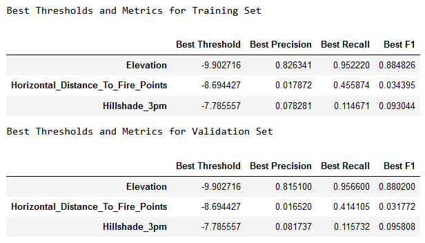

###### The best Thresholds and Metrics for Training and Validation set without any Anomalous Data

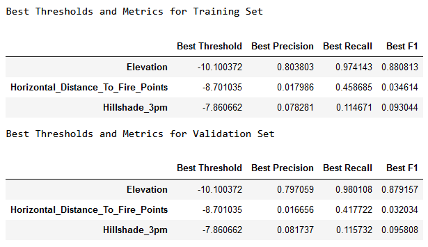

**Are these results different or similar? Why?[0.3]**

As it is apparent from the image above, there isn't any significant change in the values of the Best F1 scores in either Validation or Training set for both cases. This is because the number of Non-Anomalous data is so big when compared to the number of Anomalous data that the normal (Gaussian) distribution is not bery affected by the presence or absence of these data points.

**How would class imbalance affect any classifier in general (apart from just a KNN)? [0.2]**

Class imbalance can affect any classifier, not just KNN, in several ways:

1. **Bias:** Class imbalance can lead to a bias in the classifier's predictions towards the majority class. This is because the classifier tends to classify most instances as belonging to the majority class, even if they belong to the minority class. This bias can result in poor performance for the minority class, as the classifier may miss many instances of the minority class, leading to `False Negatives.`
2. **Low accuracy:** A classifier trained on an imbalanced dataset may have low accuracy overall, as it may perform well on the majority class but poorly on the minority class.
3. **Sensitivity and specificity:** Class imbalance can also affect the sensitivity and specificity of a classifier. `Sensitivity` measures the proportion of `True Positives` that are correctly identified, while `Specificity` measures the proportion of `True Negatives` that are correctly identified. An imbalanced dataset can cause a classifier to have high sensitivity but low specificity, or vice versa due to the high amount of `False Negatives.`
4. **Overfitting:** An imbalanced dataset can also lead to overfitting, where the classifier becomes too specialized to the training data and performs poorly on new data. This can happen if the classifier learns to overemphasize the majority class and ignores the minority class, leading to poor generalization.

In summary, class imbalance can affect any classifier in several ways, leading to biased predictions, low accuracy, poor sensitivity and specificity, and overfitting. It is important to address class imbalance in the dataset to improve the performance of the classifier.

## **Part 3: One Gaussian model with multiple features: [2 Marks]**

This part is similar to Part 2, but here we will pick multiple features and set the number of components **visually**.

1. Pick two features (say, f1 and f2).
2. Scatter plot (plt.scatter) those features of the training set on a figure (f1 on the x-axis and f2 on the y-axis). **[0.25]**
3. On the scatter plot color the training set based on their class (non-anomalous blue and anomalous red). **[0.25]**
4. Based on your plots decide how many Gaussian components (`n_components`) you need to fit the data (focus on non-anomalous forests). **[0.25]**
5. Fit your Gaussian model on the training set (all samples).
6. Compute AUC on both training and validation sets **[0.25]**
7. Pick 3 new pair of features and repeat steps 2 to 6. **[0.5]**
8. Pick the set with the highest AUC on the validation set (out of the four sets that you tried.)
9. Find a threshold to maximize your F1 Score on the validation set.**[0.25]**
10. Plot two seperate figures (one for the training data and one for the validation data) similar to step 3 and put a circle around outliers based on your threshold (use the code of the similar figure in tutorial) **[0.25]**

```python
# Steps 1 - 7

# Plotting 2 features
def two_feature_scatter(X_train, y_train, feature_1, feature_2,
                                          feature_3, feature_4,
                                          feature_5, feature_6,
                                          feature_7, feature_8):

    fig, axs = plt.subplots(2, 2, figsize = (20,16), dpi = 100)

    # 1st Pair
    axs[0, 0].scatter(x = X_train[feature_1][y_train == 0],
                      y = X_train[feature_2][y_train == 0],
                      c = 'b', marker = 'x',
                      cmap = 'bwr', alpha = 0.3609)
    axs[0, 0].scatter(x = X_train[feature_1][y_train == 1],
                      y = X_train[feature_2][y_train == 1],
                      c = 'r', marker = 'x',
                      cmap = 'bwr', alpha = 0.3609)

    axs[0, 0].set_title('Scatterplot - ' + feature_2 + ' v/s ' + feature_1)
    axs[0, 0].set_xlabel(feature_1)
    axs[0, 0].set_ylabel(feature_2)
    axs[0, 0].legend(labels = ['Non-Anomalous', 'Anomalous'])

    # 2nd Pair
    axs[0, 1].scatter(x = X_train[feature_3][y_train == 0],
                      y = X_train[feature_4][y_train == 0],
                      c = 'b', marker = 'x',
                      cmap = 'bwr', alpha = 0.3609)
    axs[0, 1].scatter(x = X_train[feature_3][y_train == 1],
                      y = X_train[feature_4][y_train == 1],
                      c = 'r', marker = 'x',
                      cmap = 'bwr', alpha = 0.3609)

    axs[0, 1].set_title('Scatterplot - ' + feature_4 + ' v/s ' + feature_3)
    axs[0, 1].set_xlabel(feature_3)
    axs[0, 1].set_ylabel(feature_4)
    axs[0, 1].legend(labels = ['Non-Anomalous', 'Anomalous'])

    # 3rd Pair
    axs[1, 0].scatter(x = X_train[feature_5][y_train == 0],
                      y = X_train[feature_6][y_train == 0],
                      c = 'b', marker = 'x',
                      cmap = 'bwr', alpha = 0.3609)
    axs[1, 0].scatter(x = X_train[feature_5][y_train == 1],
                      y = X_train[feature_6][y_train == 1],
                      c = 'r', marker = 'x',
                      cmap = 'bwr', alpha = 0.3609)

    axs[1, 0].set_title('Scatterplot - ' + feature_6 + ' v/s ' + feature_5)
    axs[1, 0].set_xlabel(feature_5)
    axs[1, 0].set_ylabel(feature_6)
    axs[1, 0].legend(labels = ['Non-Anomalous', 'Anomalous'])

    # 4th Pair
    axs[1, 1].scatter(x = X_train[feature_7][y_train == 0],
                      y = X_train[feature_8][y_train == 0],
                      c = 'b', marker = 'x',
                      cmap = 'bwr', alpha = 0.3609)
    axs[1, 1].scatter(x = X_train[feature_7][y_train == 1],
                      y = X_train[feature_8][y_train == 1],
                      c = 'r', marker = 'x',
                      cmap = 'bwr', alpha = 0.3609)

    axs[1, 1].set_title('Scatterplot - ' + feature_8 + ' v/s ' + feature_7)
    axs[1, 1].set_xlabel(feature_7)
    axs[1, 1].set_ylabel(feature_8)
    axs[1, 1].legend(labels = ['Non-Anomalous', 'Anomalous'])

    plt.show()

# AUC calculation for Train and Validation set for each Pair
def AUC_Train_Val_comparison(X_train, y_train, feature_1, feature_2, n = 1):

    # Lists for AUC scores
    AUC_train_multiple_feat_list = []
    AUC_val_multiple_feat_list = []

    # Gaussian model for multiple features
    gm_multiple = GaussianMixture(n_components = n, random_state = 0) # Model
    gm_multiple.fit(X_train[[feature_1, feature_2]].values) # Model Fitting

    # AUC for Train and Validation sets
    train_score = gm_multiple.score_samples(X_train[[feature_1, feature_2]].values) # Train set
    val_score = gm_multiple.score_samples(X_val[[feature_1, feature_2]].values) # Validation set

    # Appending Lists for Train and Validation sets
    AUC_train_multiple_feat_list.append(roc_auc_score(y_train, -1 * train_score)) # Train set
    AUC_val_multiple_feat_list.append(roc_auc_score(y_val, -1 * val_score)) # Validation set

    # convert all AUC outputs into table(dataframe form)
    df_auc_gm_mul = pd.DataFrame({'Gaussian Components': n,
                                  'Train set AUC': AUC_train_multiple_feat_list,
                                  'Validation set AUC': AUC_val_multiple_feat_list},
                                 index = [str(feature_1 + ' & ' + feature_2)])
    print('AUC Scores for ' + feature_1 + ' & ' + feature_2)
    return show.display(df_auc_gm_mul)
```

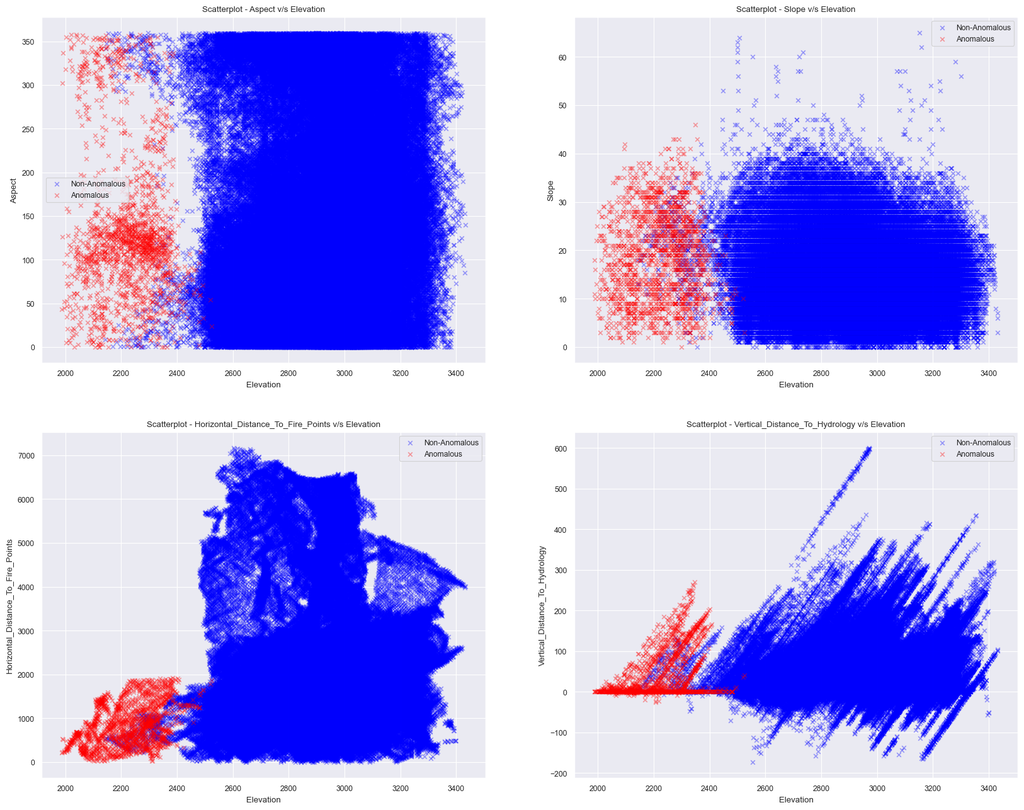

```
AUC Scores for Elevation & Aspect
```

|  | Gaussian Components | Train set AUC | Validation set AUC |
| --- | --- | --- | --- |
| Elevation & Aspect | 1 | 0.998229 | 0.998017 |

```
AUC Scores for Elevation & Slope
```

|  | Gaussian Components | Train set AUC | Validation set AUC |
| --- | --- | --- | --- |
| Elevation & Slope | 1 | 0.995338 | 0.99554 |

```
AUC Scores for Elevation & Horizontal_Distance_To_Fire_Points
```

|  | Gaussian Components | Train set AUC | Validation set AUC |
| --- | --- | --- | --- |
| Elevation & Horizontal_Distance_To_Fire_Points | 1 | 0.993719 | 0.993396 |

```
AUC Scores for Elevation & Vertical_Distance_To_Hydrology
```

|  | Gaussian Components | Train set AUC | Validation set AUC |
| --- | --- | --- | --- |
| Elevation & Vertical_Distance_To_Hydrology | 1 | 0.987141 | 0.987107 |

```python
# The 4 Scatterplots for 8 features
two_feature_scatter(X_train, y_train, 'Elevation', 'Aspect',
                                      'Elevation', 'Slope',
                                      'Elevation', 'Horizontal_Distance_To_Fire_Points',
                                      'Elevation', 'Vertical_Distance_To_Hydrology')

# The AUCs for the 4 Graphs with 8 features respectively
AUC_Train_Val_comparison(X_train, y_train, 'Elevation', 'Aspect', n = 1)
AUC_Train_Val_comparison(X_train, y_train, 'Elevation', 'Slope', n = 1)
AUC_Train_Val_comparison(X_train, y_train, 'Elevation', 'Horizontal_Distance_To_Fire_Points', n = 1)
AUC_Train_Val_comparison(X_train, y_train, 'Elevation', 'Vertical_Distance_To_Hydrology', n = 1)
```

|  | Threshold | F1 Score |
| --- | --- | --- |
| Elevation & Aspect | -16.325977 | 0.801702 |

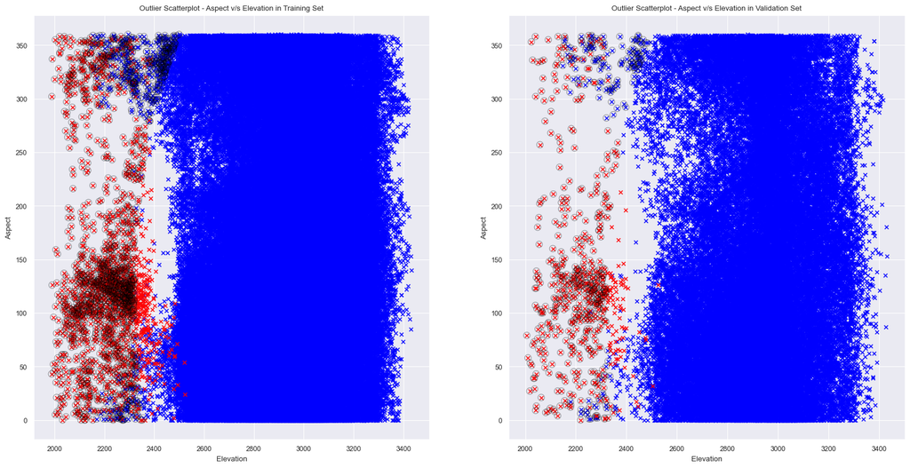

```python
# Step 8 = Best Pair is 'Elevation' & 'Aspect'

# Step 9

# Gaussian Distribution for Top 2 Features
gm_ele_asp = GaussianMixture(n_components = 1, random_state = 0)
gm_ele_asp.fit(X_train[['Elevation', 'Aspect']].values)

# AUC scores on Train and Validation sets
train_score = gm_ele_asp.score_samples(X_train[['Elevation', 'Aspect']].values)
val_score = gm_ele_asp.score_samples(X_val[['Elevation', 'Aspect']].values)

# Finding the F1 Score and respective Thresholds from Validation set only.
df_ele_asp_based_f1_pred = f1_score_by_threshold(val_score, y_val)

# Threshold, Prediction and F1 Score when F1 Score is maximized.
ele_asp_best_threshold, ele_asp_best_pred, ele_asp_best_f1_val = best_f1_score_and_threshold(df_ele_asp_based_f1_pred)

ele_asp_best = pd.DataFrame({'Threshold': ele_asp_best_threshold, 'F1 Score': ele_asp_best_f1_val}, index = ['Elevation & Aspect'])
show.display(ele_asp_best)

# Step 10

fig, axs = plt.subplots(1, 2, figsize = (20, 10), dpi = 100)

# Training set Outlier Scatterplot
axs[0].set_title('Outlier Scatterplot - Aspect v/s Elevation in Training Set')
axs[0].scatter(x = X_train['Elevation'][y_train == 0],
                y = X_train['Aspect'][y_train == 0],
                c = 'b', marker = 'x',
                cmap = 'bwr', alpha = 0.9036)
axs[0].scatter(x = X_train['Elevation'][y_train == 1],
                y = X_train['Aspect'][y_train == 1],
                c = 'r', marker = 'x',
                cmap = 'bwr', alpha = 0.9036)
outliers = np.nonzero(train_score < ele_asp_best_threshold)[0]
axs[0].scatter(X_train['Elevation'].iloc[outliers], X_train['Aspect'].iloc[outliers],
            marker = 'o', facecolor = 'none', edgecolor = 'black', s = 70, alpha = 0.369)
axs[0].set_xlabel('Elevation')
axs[0].set_ylabel('Aspect')

# Validation set Outlier Scatterplot
axs[1].set_title('Outlier Scatterplot - Aspect v/s Elevation in Validation Set')
axs[1].scatter(x = X_val['Elevation'][y_val == 0],
                y = X_val['Aspect'][y_val == 0],
                c = 'b', marker = 'x',
                cmap = 'bwr', alpha = 0.9036)
axs[1].scatter(x = X_val['Elevation'][y_val == 1],
                y = X_val['Aspect'][y_val == 1],
                c = 'r', marker = 'x',
                cmap = 'bwr', alpha = 0.9036)
outliers = np.nonzero(val_score < ele_asp_best_threshold)[0]
axs[1].scatter(X_val['Elevation'].iloc[outliers], X_val['Aspect'].iloc[outliers],
            marker = 'o', facecolor = 'none', edgecolor = 'black', s = 70, alpha = 0.369)
axs[1].set_xlabel('Elevation')
axs[1].set_ylabel('Aspect')

plt.show()
```

## **Part 4: Two Gaussian model with single feature. [3 Marks]**

Now we will use two separate distributions for anomalous and non-anomalous forests.

1. Fit a Gaussian distribution ($G_1$) on a feature of **non-anomalous forests** using `sklearn.mixture.GaussianMixture` when `n_components=1`. **[0.5]**
2. Fit another Gaussian distribution ($G_2$) on the same feature but for **anomalous forests** using `sklearn.mixture.GaussianMixture` when `n_components=1`. **[0.5]**
3. Compute the score samples ($S$) for both $G_1$ and $G_2$ on the **validation set** to get $S_1$ and $S_2$, respectively. **[0.5]**
4. Find an optimal $c$ (a real number) that maximizes validation set F1 Score for a model such that if $S_1 < c \times S_2$, the forest is classified as anomalous. For example, if $c=1$ we could say that if $S_2$ is greater than $S_1$, ($S_1$<$S_2$) then the forest is anomalous (the forest belongs to the $G_2$ distribution which represents anomalous forests). For start consider $c$ in $[0,10]$ with steps of 0.1, you can change this window in your experiments if needed. **[0.5]**
5. Repeat the steps above for all the features. What is the best F1 Score, Precision and Recall that you get for training and validation? Which feature and what c? Show your results in a table. **[0.5]**
6. Can we report AUC for this model? Why? **[0.5]**

```python
# Empty  Validation table list for Storage
validation_table = []

for feature in features:

    # Filtering the data for Non-Anomalous and Anomalous type.
    X_train_na_feat = X_train[feature][y_train==0].values.reshape(-1,1) # Non-Anomalous
    X_train_a_feat = X_train[feature][y_train==1].values.reshape(-1,1) # Anomalous

    # Gaussian Models for Non-Anomalous and Anomalous Data respectively.
    G1 = GaussianMixture(n_components=1, random_state=0) # Non-Anomalous
    G2 = GaussianMixture(n_components=1, random_state=0) # Anomalous

    # Fitting the models on the Train set respectively.
    G1.fit(X_train_na_feat)
    G2.fit(X_train_a_feat)

    # AUC scores on Validation set only.
    S1 = G1.score_samples(X_val[feature].values.reshape(-1,1)) # Non-Anomalous
    S2 = G2.score_samples(X_val[feature].values.reshape(-1,1)) # Anomalous

    # Variables initialised to 0
    c = 0
    max_c = 0
    max_f1 = 0
    precision = 0
    recall = 0

    while(c <= 10):
        f1 = f1_score(y_val, S1 < (c * S2))
        if(max_f1 < f1):
            max_f1 = f1
            max_c = c
            precision = precision_score(y_val, S1 < (c * S2))
            recall = recall_score(y_val, S1 < (c * S2))
        c += 0.1

    validation_table.append([max_c, max_f1, recall, precision])

validation_table = pd.DataFrame(np.array(validation_table),
                                columns = ['c', 'Validation F1 Score', 'Validation Recall', 'Validation Precision'],
                                index = features)
```

```python
# Empty  train table list for Storage
train_table = []

for feature in features:

    # Filtering the data for Non-Anomalous and Anomalous type.
    X_train_na_feat = X_train[feature][y_train==0].values.reshape(-1,1) # Non-Anomalous
    X_train_a_feat = X_train[feature][y_train==1].values.reshape(-1,1) # Anomalous

    # Gaussian Models for Non-Anomalous and Anomalous Data respectively.
    G1 = GaussianMixture(n_components=1, random_state=0) # Non-Anomalous
    G2 = GaussianMixture(n_components=1, random_state=0) # Anomalous

    # Fitting the models on the Train set respectively.
    G1.fit(X_train_na_feat)
    G2.fit(X_train_a_feat)

    # AUC scores on Train set only.
    S1 = G1.score_samples(X_train[feature].values.reshape(-1,1)) # Non-Anomalous
    S2 = G2.score_samples(X_train[feature].values.reshape(-1,1)) # Anomalous

    # To match the same C values from Validation table
    max_c = validation_table['c'][feature]

    max_f1 = f1_score(y_train, S1 < (max_c * S2))
    precision = precision_score(y_train, S1 < (max_c * S2))
    recall = recall_score(y_train, S1 < (max_c * S2))

    train_table.append([max_c, precision, recall, max_f1])

train_table = pd.DataFrame(np.array(train_table),
                           columns = ['c', 'Train F1 Score', 'Train Recall', 'Train Precision'],
                           index = features)
```

```python
# Resetting the Index of both tables
train_table.reset_index(inplace=True)
validation_table.reset_index(inplace=True)

# Merging, Renaming and Resetting the Index to Features
tv_table = train_table.merge(validation_table, on = ['index', 'c'])
tv_table.rename(columns={"index": "Features"}, inplace=True)
tv_table.set_index('Features', drop=True, inplace=True)

show.display(tv_table)
```

| Features | c | Train F1 Score | Train Recall | Train Precision | Validation F1 Score | Validation Recall | Validation Precision |
| --- | --- | --- | --- | --- | --- | --- | --- |
| Elevation | 1.6 | 0.832175 | 0.942102 | 0.883733 | 0.875421 | 0.940325 | 0.818898 |
| Aspect | 1.0 | 0.011527 | 0.816189 | 0.022733 | 0.023574 | 0.842676 | 0.011954 |
| Slope | 1.4 | 0.045633 | 0.143901 | 0.069292 | 0.072386 | 0.146474 | 0.048071 |
| Horizontal_Distance_To_Hydrology | 1.1 | 0.022111 | 0.690838 | 0.042851 | 0.042778 | 0.681736 | 0.022082 |
| Vertical_Distance_To_Hydrology | 1.0 | 0.015045 | 0.630129 | 0.029388 | 0.028564 | 0.603978 | 0.014628 |
| Horizontal_Distance_To_Roadways | 1.1 | 0.026774 | 0.882518 | 0.051971 | 0.053082 | 0.896926 | 0.027350 |
| Hillshade_9am | 1.1 | 0.032414 | 0.456436 | 0.060529 | 0.060798 | 0.450271 | 0.032600 |
| Hillshade_Noon | 1.1 | 0.020201 | 0.229342 | 0.037131 | 0.036062 | 0.224231 | 0.019608 |
| Hillshade_3pm | 1.3 | 0.086894 | 0.203485 | 0.121783 | 0.118543 | 0.197107 | 0.084759 |
| Horizontal_Distance_To_Fire_Points | 1.2 | 0.026725 | 0.365374 | 0.049807 | 0.047094 | 0.343580 | 0.025279 |

**What is the best F1 Score, Precision and Recall that you get for training and validation? Which feature and what c? [0.5]**

*`Validation Set`*

- Best Feature = **`Elevation`**
- Best c = **`1.6`**
- Best F1 Score = **`0.875421`**
- Best Recall = **`0.940325`**
- Best Precision = **`0.818898`**

**Can we report AUC for this model? Why? [0.5]**

We cannot report AUC for this model because AUC requires a binary classifier (built-in threshold). Also, because the AUC is the area under the Receiver Operating Characteristic (ROC) curve, which plots the True Positive Rate (TPR) against the False Positive Rate (FPR) at different thresholds. Since we need to choose a threshold for this model, we cannot report AUC directly.

## **Part 5: Multivariate and Mixture of Gaussians Distribution [3 Marks]**

We now want to build an outlier detection model that performs well in terms of F1 score. To design your model, you can benefit from:

- No restrictions on the number of features - use as few or as many as you want! (multivariate).
- To fit your model, you can take advantage of the Gaussian mixture model where you can set the number of components [help](https://scikit-learn.org/stable/modules/generated/sklearn.mixture.GaussianMixture.html).
- You can choose to fit your Gaussians on non-anomalous forests or to both classes.

It is up to you how to design your model. Try at least 10 different models and report the AUC for both training and validation sets (if applicable) and the best F1 score, Precision and Recall (after tuning the threshold) for both training and validation sets for each model. What kind of model works better? How many features are best (and which ones)? How many Gaussians? How many components? Summarize your findings with tables or plots. **[3]**

**HINT !**

You might want to try a two gaussian model, multiple features, single component for valid forests and multiple components for anomalous ones! Why does it make sense to have multiple components for the anomalous forests?

```python
def multivariate_gm_multiple(X_train, X_val, y_train, y_val, X_test, y_test, features, n, table, test_mode=False, c_test = 0):

    if test_mode: # if test_mode is True: (Default = False)

        # Filtering the data for Non-Anomalous and Anomalous type.
        X_train_na_feat = X_train[features][y_train==0].values # Non-Anomalous
        X_train_a_feat = X_train[features][y_train==1].values # Anomalous

        # Gaussian Models for Non-Anomalous and Anomalous Data respectively.
        GMM_1 = GaussianMixture(n_components=1, random_state=0) # Non-Anomalous
        GMM_2 = GaussianMixture(n_components=n, random_state=0) # Anomalous

        # Fitting the models on the Train set respectively.
        GMM_1.fit(X_train_na_feat)
        GMM_2.fit(X_train_a_feat)

        # AUC scores on Test set only.
        S1_test = GMM_1.score_samples(X_test[features].values) # Non-Anomalous
        S2_test = GMM_2.score_samples(X_test[features].values) # Anomalous

        # Variables initialised to 0
        max_f1_test = 0 # Validation
        precision_test = 0 # Validation
        recall_test = 0 # Validation

        max_f1_test = f1_score(y_test, S1_test < (c_test * S2_test))
        precision_test = precision_score(y_test, S1_test < (c_test * S2_test))
        recall_test = recall_score(y_test, S1_test < (c_test * S2_test))

        table.append([len(features), n, c_test,
                      precision_test, recall_test, max_f1_test])

    else:

        # Filtering the data for Non-Anomalous and Anomalous type.
        X_train_na_feat = X_train[features][y_train==0].values # Non-Anomalous
        X_train_a_feat = X_train[features][y_train==1].values # Anomalous

        # Gaussian Models for Non-Anomalous and Anomalous Data respectively.
        GMM_1 = GaussianMixture(n_components=1, random_state=0) # Non-Anomalous
        GMM_2 = GaussianMixture(n_components=n, random_state=0) # Anomalous

        # Fitting the models on the Train set respectively.
        GMM_1.fit(X_train_na_feat)
        GMM_2.fit(X_train_a_feat)

        # AUC scores on Train set only.
        S1_train = GMM_1.score_samples(X_train[features].values) # Non-Anomalous
        S2_train = GMM_2.score_samples(X_train[features].values) # Anomalous

        # AUC scores on Validation set only.
        S1_val = GMM_1.score_samples(X_val[features].values) # Non-Anomalous
        S2_val = GMM_2.score_samples(X_val[features].values) # Anomalous

        # Variables initialised to 0
        c_val = 0 # Validation
        c_train = 0 # Train

        max_f1_val = 0 # Validation
        max_f1_train = 0 # Train

        precision_val = 0 # Validation
        precision_train = 0 # Train

        recall_val = 0 # Validation
        recall_train = 0 # Train

        while(c_val <= 10):
            f1 = f1_score(y_val, S1_val < (c_val * S2_val))
            if(max_f1_val < f1):
                max_f1_val = f1
                c_train = c_val
                precision_val = precision_score(y_val, S1_val < (c_val * S2_val))
                recall_val = recall_score(y_val, S1_val < (c_val * S2_val))
            c_val += 0.1

        max_f1_train = f1_score(y_train, S1_train < (c_train * S2_train))
        precision_train = precision_score(y_train, S1_train < (c_train * S2_train))
        recall_train = recall_score(y_train, S1_train < (c_train * S2_train))

        table.append([len(features), n, c_train,
                      precision_train, recall_train, max_f1_train,
                      precision_val, recall_val, max_f1_val])
```

```python
print('The Features List is provided below as follows:')
show.display(features)

# To store the final result
final_table = []

print('"For" loop Processing: ', end='', flush = True)

for feat in range(1,11):
    for n in range(1,6,1):
        # print('Features: ', feat, ' & ', 'Gaussian Components: ', n)
        print('..', end='', flush = True)
        multivariate_gm_multiple(X_train, X_val, y_train, y_val, X_test, y_test, features[:feat], n, final_table, test_mode=False, c_test = 0)
#         multivariate_gm_multiple(X_train, X_val, y_train, y_val, features[:feat], n, final_table)
```

```
The Features List is provided below as follows:
```

```
['Elevation',
 'Aspect',
 'Slope',
 'Horizontal_Distance_To_Hydrology',
 'Vertical_Distance_To_Hydrology',
 'Horizontal_Distance_To_Roadways',
 'Hillshade_9am',
 'Hillshade_Noon',
 'Hillshade_3pm',
 'Horizontal_Distance_To_Fire_Points']
```

```
"For" loop Processing: ....................................................................................................
```

```python
final_table = pd.DataFrame(final_table,
                           columns = ['No. of Features','Gaussian Components','c - Value',
                                      'Training Precision', 'Training Recall' , 'Training F1 Score',
                                      'Validation Precision', 'Validation Recall', 'Validation F1 Score'])
final_table.set_index(['No. of Features','Gaussian Components'], drop = True, inplace=True)

show.display(final_table)
```

| No. of Features | Gaussian Components | c - Value | Training Precision | Training Recall | Training F1 Score | Validation Precision | Validation Recall | Validation F1 Score |
| --- | --- | --- | --- | --- | --- | --- | --- | --- |
| 1 | 1 | 1.6 | 0.832175 | 0.942102 | 0.883733 | 0.818898 | 0.940325 | 0.875421 |
|  | 2 | 1.6 | 0.824988 | 0.953907 | 0.884776 | 0.812596 | 0.956600 | 0.878738 |
|  | 3 | 1.5 | 0.808322 | 0.971894 | 0.882593 | 0.797637 | 0.976492 | 0.878049 |
|  | 4 | 1.5 | 0.811294 | 0.969084 | 0.883197 | 0.798519 | 0.974684 | 0.877850 |
|  | 5 | 1.5 | 0.814780 | 0.966835 | 0.884319 | 0.801802 | 0.965642 | 0.876128 |
| 2 | 1 | 1.3 | 0.836283 | 0.956155 | 0.892211 | 0.820711 | 0.960217 | 0.885000 |
|  | 2 | 1.3 | 0.836897 | 0.946037 | 0.888127 | 0.828660 | 0.962025 | 0.890377 |
|  | 3 | 1.4 | 0.861810 | 0.904441 | 0.882611 | 0.854484 | 0.913201 | 0.882867 |
|  | 4 | 1.3 | 0.829340 | 0.953345 | 0.887029 | 0.824074 | 0.965642 | 0.889259 |
|  | 5 | 1.3 | 0.833825 | 0.953345 | 0.889588 | 0.822430 | 0.954792 | 0.883682 |
| 3 | 1 | 1.2 | 0.806391 | 0.964587 | 0.878423 | 0.797637 | 0.976492 | 0.878049 |
|  | 2 | 1.3 | 0.886224 | 0.893198 | 0.889698 | 0.879646 | 0.898734 | 0.889088 |
|  | 3 | 1.3 | 0.876078 | 0.913997 | 0.894635 | 0.863322 | 0.902351 | 0.882405 |
|  | 4 | 1.3 | 0.899554 | 0.906127 | 0.902828 | 0.895575 | 0.915009 | 0.905188 |
|  | 5 | 1.3 | 0.902071 | 0.906127 | 0.904094 | 0.898936 | 0.916817 | 0.907789 |
| 4 | 1 | 1.2 | 0.841775 | 0.906127 | 0.872767 | 0.832787 | 0.918626 | 0.873603 |
|  | 2 | 1.2 | 0.924890 | 0.948286 | 0.936442 | 0.924694 | 0.954792 | 0.939502 |
|  | 3 | 1.2 | 0.921951 | 0.956155 | 0.938742 | 0.918544 | 0.958409 | 0.938053 |
|  | 4 | 1.2 | 0.927560 | 0.957279 | 0.942185 | 0.918089 | 0.972875 | 0.944688 |
|  | 5 | 1.3 | 0.583543 | 0.912872 | 0.711968 | 0.574686 | 0.911392 | 0.704895 |
| 5 | 1 | 1.2 | 0.864578 | 0.868465 | 0.866517 | 0.852837 | 0.869801 | 0.861235 |
|  | 2 | 1.2 | 0.905992 | 0.926363 | 0.916064 | 0.899480 | 0.938517 | 0.918584 |
|  | 3 | 4.8 | 0.916121 | 0.392917 | 0.549961 | 0.907950 | 0.392405 | 0.547980 |
|  | 4 | 4.8 | 0.916121 | 0.392917 | 0.549961 | 0.907950 | 0.392405 | 0.547980 |
|  | 5 | 4.8 | 0.916121 | 0.392917 | 0.549961 | 0.907950 | 0.392405 | 0.547980 |
| 6 | 1 | 1.2 | 0.936306 | 0.826307 | 0.877874 | 0.930894 | 0.828210 | 0.876555 |
|  | 2 | 1.2 | 0.929795 | 0.915683 | 0.922685 | 0.919355 | 0.927667 | 0.923492 |
|  | 3 | 1.2 | 0.429424 | 0.930298 | 0.587609 | 0.430614 | 0.925859 | 0.587830 |
|  | 4 | 1.2 | 0.430102 | 0.947723 | 0.591683 | 0.434211 | 0.954792 | 0.596947 |
|  | 5 | 1.2 | 0.430399 | 0.945475 | 0.591525 | 0.432365 | 0.942134 | 0.592719 |
| 7 | 1 | 1.1 | 0.859206 | 0.936481 | 0.896181 | 0.839744 | 0.947559 | 0.890399 |
|  | 2 | 1.2 | 0.903691 | 0.880832 | 0.892115 | 0.905556 | 0.884268 | 0.894785 |
|  | 3 | 1.2 | 0.427793 | 0.882518 | 0.576253 | 0.430809 | 0.895118 | 0.581669 |
|  | 4 | 1.2 | 0.438778 | 0.928612 | 0.595960 | 0.441152 | 0.942134 | 0.600923 |
|  | 5 | 1.2 | 0.439108 | 0.940416 | 0.598676 | 0.436027 | 0.936709 | 0.595060 |
| 8 | 1 | 1.1 | 0.885517 | 0.934795 | 0.909489 | 0.873122 | 0.945750 | 0.907986 |
|  | 2 | 1.2 | 0.903396 | 0.867341 | 0.885001 | 0.901487 | 0.877034 | 0.889093 |
|  | 3 | 1.2 | 0.433557 | 0.872962 | 0.579370 | 0.440860 | 0.889693 | 0.589575 |
|  | 4 | 1.2 | 0.449459 | 0.934795 | 0.607045 | 0.455334 | 0.949367 | 0.615475 |
|  | 5 | 1.2 | 0.448680 | 0.946037 | 0.608680 | 0.451502 | 0.951175 | 0.612340 |
| 9 | 1 | 1.1 | 0.859521 | 0.928612 | 0.892732 | 0.868114 | 0.940325 | 0.902778 |
|  | 2 | 1.2 | 0.928482 | 0.831928 | 0.877557 | 0.944330 | 0.828210 | 0.882466 |
|  | 3 | 1.1 | 0.412683 | 0.980326 | 0.580849 | 0.418909 | 0.985533 | 0.587918 |
|  | 4 | 1.2 | 0.441734 | 0.916245 | 0.596087 | 0.444346 | 0.909584 | 0.597033 |
|  | 5 | 1.2 | 0.448017 | 0.939854 | 0.606786 | 0.453287 | 0.947559 | 0.613224 |
| 10 | 1 | 1.1 | 0.854922 | 0.927487 | 0.889728 | 0.864238 | 0.943942 | 0.902334 |
|  | 2 | 1.1 | 0.858495 | 0.968522 | 0.910195 | 0.843354 | 0.963834 | 0.899578 |
|  | 3 | 1.2 | 0.917233 | 0.834739 | 0.874044 | 0.925636 | 0.855335 | 0.889098 |
|  | 4 | 1.2 | 0.523716 | 0.899944 | 0.662117 | 0.528541 | 0.904159 | 0.667111 |
|  | 5 | 1.2 | 0.549191 | 0.916245 | 0.686750 | 0.549892 | 0.916817 | 0.687458 |

```python
# Best Gaussian Model

best_feature = final_table.nlargest(1, 'Validation F1 Score')
show.display(best_feature)
```

| No. of Features | Gaussian Components | c - Value | Training Precision | Training Recall | Training F1 Score | Validation Precision | Validation Recall | Validation F1 Score |
| --- | --- | --- | --- | --- | --- | --- | --- | --- |
| 4 | 4 | 1.2 | 0.92756 | 0.957279 | 0.942185 | 0.918089 | 0.972875 | 0.944688 |

**What kind of model works better? How many features are best (and which ones)? How many Gaussians? How many components?**

As seen from the table above a combination of 4 feaures and 4 gaussian components with a threshold of 1.2 provides the best validation F1 Score.

- Number of Features: **`4`**
- Features used: **`'Elevation','Aspect', 'Slope', 'Horizontal_Distance_To_Hydrology'`**
- Gaussian Components: **`4`**
- c - Value: **`1.2`**
- Train and Validation Precision: **`0.92756 & 0.918089`**
- Train and Validation Recall: **`0.0.957279 & 0.0.972875`**
- Train and Validation F1 Score: **`0.942185 & 0.944688`**

**Why does it make sense to have multiple components for the anomalous forests?**

Having multiple components for anomalous forests makes sense because anomalous forests may have different characteristics that make them anomalous. By using multiple components in the model, we can capture the different characteristics and identify anomalous forests more accurately. In contrast, valid forests may have more uniform characteristics, so a single component model with multiple features may be sufficient to capture their properties.

Moreover, this is because non-anomalous data typically clusters together, whereas anomalous data may be scattered in different directions. If we use a single component to model anomalous data, it may only capture the most extreme instances of anomalous data, leaving out other instances that are not closely associated with this component. As a result, these other instances may be misclassified as non-anomalous data. To better capture the full range of anomalous data, it may be necessary to use multiple components.

## **Part 6: Evaluating performance on test set: [1 Mark]**

**Which model worked better?** Pick your best model among all models and apply it to your test set. Report the F1 Score, Precision and Recall on the test set. **[1]**

The best model is decreibed as above and applied on the Test set and the results are shown below.

```python
# Store the Test Values and the Features used for Testing
test_table = []
test_features = ['Elevation','Aspect', 'Slope', 'Horizontal_Distance_To_Hydrology']

# Function calling
multivariate_gm_multiple(X_train, X_val, y_train, y_val, X_test, y_test, test_features, 4, test_table, test_mode=True, c_test = 1.2)
```

```python
# Final Test Table
test_table = pd.DataFrame(test_table, columns = ['No. of Features','Gaussian Components','c - Value',
                                                 'Test Precision', 'Test Recall' , 'Test F1 Score'])
test_table.set_index(['No. of Features','Gaussian Components'], drop = True, inplace=True)

show.display(test_table)
```

| No. of Features | Gaussian Components | c - Value | Test Precision | Test Recall | Test F1 Score |
| --- | --- | --- | --- | --- | --- |
| 4 | 4 | 1.2 | 0.925754 | 0.961446 | 0.943262 |

## **Bonus Part: Using the Precision Recall Curve: [1 Mark]**

Repeat Part 2 using the Precision Recall Curve instead of the ROC curve.

### Part 2.a.

```python
# X_train_na = X_train[y_train==0]
# y_train_na = y_train[y_train==0]

# Step 1 - 3

features = [f for f in df.columns if not 'id' in f and not 'Anomaly' in f]

# Lists for PRC outputs
PRC_train_single_feat_list = []
PRC_val_single_feat_list = []

for feature in features:

    # Gaussian model for single feature
    gm_single = GaussianMixture(n_components = 1, random_state = 0)

    # Fitting a single normal distribution on a single feature
    gm_single.fit(X_train[feature].values.reshape(-1, 1))

    # Find scores on Train set and Validation set
    train_score = gm_single.score_samples(X_train[feature].values.reshape(-1, 1))
    val_score = gm_single.score_samples(X_val[feature].values.reshape(-1, 1))

    # Compute Precision, Recall and Thresholds on Train and Validation set
    precision_train, recall_train, thresholds_train = precision_recall_curve(y_train, train_score)
    precision_val, recall_val, thresholds_val = precision_recall_curve(y_val, val_score)

    # Find AUC on Train set and Validation set and add to Lists
    PRC_train_single_feat_list.append(auc(recall_train, precision_train))
    PRC_val_single_feat_list.append(auc(recall_val, precision_val))

# PRC Outputs as DataFrame
PRC_list = {'Train Set PRC': PRC_train_single_feat_list, 'Validation Set PRC': PRC_val_single_feat_list}
df_PRC = pd.DataFrame(PRC_list, index = df.columns[0:10])
print('PRC for Train and Validation Sets')
show.display(df_PRC)

# Step 4

# Top 3 Features based on Validation set AUC
max_feat_name = df_PRC.nlargest(3, 'Validation Set PRC')
print('Top 3 Features')
show.display(max_feat_name)
max_feat_name = max_feat_name.index

# Step 5 - 6

# Find thresholds that Maximize F1 score
best_threshold_list = []

# Lists for F1 score, Precision, & Recall for Validation Set
best_val_f1_score_list = []
best_val_precision_list = []
best_val_recall_list = []

# Lists for F1 score, Precision, & Recall for Train Set
best_train_f1_score_list = []
best_train_precision_list = []
best_train_recall_list = []

for feature in max_feat_name:

    # Gaussian model for single feature
    gm_single = GaussianMixture(n_components = 1, random_state = 0)

    # Fitting a single normal distribution on a single feature
    gm_single.fit(X_train[feature].values.reshape(-1, 1))

    # Finding the scores in Train and Validation set
    train_score = gm_single.score_samples(X_train[feature].values.reshape(-1, 1))
    val_score = gm_single.score_samples(X_val[feature].values.reshape(-1, 1))

    # Finding the F1 Score and respective Thresholds from Validation set only.
    df_thr_based_f1_pred = f1_score_by_threshold(val_score, y_val)

    # Threshold, Prediction and F1 Score when F1 Score is maximized
    best_threshold, best_pred, best_f1_val = best_f1_score_and_threshold(df_thr_based_f1_pred)

    # Appending Optimized Threshhold to List
    best_threshold_list.append(best_threshold)

    # Precision and Recall for Max F1 Scores and Best Thresholds for Train and Validation set
    best_train_precision, best_train_recall, best_train_f1_score = precision_recall_f1_with_threshold(train_score, y_train, best_threshold)
    best_val_precision, best_val_recall, best_val_f1_score = precision_recall_f1_with_threshold(val_score, y_val, best_threshold)

    # Train Set Lists
    best_train_f1_score_list.append(best_train_f1_score) # F1 Score
    best_train_precision_list.append(best_train_precision) # Precision
    best_train_recall_list.append(best_train_recall) # Recall

    # Validation Set Lists
    best_val_f1_score_list.append(best_f1_val) # F1 Score
    best_val_precision_list.append(best_val_precision) # Precision
    best_val_recall_list.append(best_val_recall) # Recall

# Best Threshold with corresponding F1 Scores
opt_thr = pd.DataFrame({'Best Threshold': best_threshold_list,
                        'Best F1': best_val_f1_score_list},
                       index = max_feat_name)
print('Best Thresholds and F1 scores from Validation set')
show.display(opt_thr)

# Best F1 Score, Precision, Recall and Thresholds for Train set
train_metrics = pd.DataFrame({'Best Threshold': best_threshold_list,
                              'Best Precision': best_train_precision_list,
                              'Best Recall': best_train_recall_list,
                              'Best F1': best_train_f1_score_list},
                             index = max_feat_name)
print('Best Thresholds and Metrics for Training Set')
show.display(train_metrics)

# Best F1 Score, Precision, Recall and Thresholds for Validation set
validation_metrics = pd.DataFrame({'Best Threshold': best_threshold_list,
                                   'Best Precision': best_val_precision_list,
                                   'Best Recall': best_val_recall_list,
                                   'Best F1': best_val_f1_score_list},
                                  index = max_feat_name)
print('Best Thresholds and Metrics for Validation Set')
show.display(validation_metrics)
```

```
PRC for Train and Validation Sets
```

|  | Train Set PRC | Validation Set PRC |
| --- | --- | --- |
| Elevation | 0.004800 | 0.004850 |
| Aspect | 0.016023 | 0.014361 |
| Slope | 0.020331 | 0.023129 |
| Horizontal_Distance_To_Hydrology | 0.012446 | 0.012579 |
| Vertical_Distance_To_Hydrology | 0.007758 | 0.007859 |
| Horizontal_Distance_To_Roadways | 0.007158 | 0.007162 |
| Hillshade_9am | 0.010640 | 0.013727 |
| Hillshade_Noon | 0.024349 | 0.023355 |
| Hillshade_3pm | 0.009770 | 0.011655 |
| Horizontal_Distance_To_Fire_Points | 0.006379 | 0.006544 |

```
Top 3 Features
```

|  | Train Set PRC | Validation Set PRC |
| --- | --- | --- |
| Hillshade_Noon | 0.024349 | 0.023355 |
| Slope | 0.020331 | 0.023129 |
| Aspect | 0.016023 | 0.014361 |

```
Best Thresholds and F1 scores from Validation set
```

|  | Best Threshold | Best F1 |
| --- | --- | --- |
| Hillshade_Noon | -5.682314 | 0.033887 |
| Slope | -4.892627 | 0.078049 |
| Aspect | -6.976518 | 0.011282 |

```
Best Thresholds and Metrics for Training Set
```

|  | Best Threshold | Best Precision | Best Recall | Best F1 |
| --- | --- | --- | --- | --- |
| Hillshade_Noon | -5.682314 | 0.025449 | 0.116358 | 0.041763 |
| Slope | -4.892627 | 0.041488 | 0.196178 | 0.068492 |
| Aspect | -6.976518 | 0.006277 | 0.054525 | 0.011258 |

```
Best Thresholds and Metrics for Validation Set
```

|  | Best Threshold | Best Precision | Best Recall | Best F1 |
| --- | --- | --- | --- | --- |
| Hillshade_Noon | -5.682314 | 0.020668 | 0.094033 | 0.033887 |
| Slope | -4.892627 | 0.047581 | 0.216998 | 0.078049 |
| Aspect | -6.976518 | 0.006296 | 0.054250 | 0.011282 |

**Report the complexity of your method (Big O notation) for determining the optimal threshold.[0.3]**

The time complexity of the given code depends on the complexity of the functions used. Here is the Big O notation for each of the functions:

*Defined Functions*

- f1_score_by_threshold: **O(n<sup>2</sup> + n)**
- best_f1_score_and_threshold: **O(n)**
- precision_recall_f1_with_threshold: **O(n)**

*Steps 1 - 3*

- Features for loop: **O(n)**
- Gaussian Models for loop: **O(n)**

*Step 4*

- nlargest (Sorting method): **O(nlogn)**

*Step 5 - 6*

- Features for loop for Models: **O(n)**
  - f1_score_by_threshold: **O(n^2 + n)**
  - best_f1_score_and_threshold: **O(n)**
  - precision_recall_f1_with_threshold: **O(n)**
  - precision_recall_f1_with_threshold: **O(n)**

Overall Model Complexity = **O(n<sup>2</sup>) + O(n) + O(n) + O(n) + O(n) + O(nlogon) + O(n)(O(n<sup>2</sup>) + O(n) + O(n) + O(n))**

Results ----> **O(n<sup>3</sup>) + 4.O(n<sup>2</sup>) + 4.O(n) + O(nlogn)**

Therefore, the overall time complexity of the given code is **O(n<sup>3</sup>)** because the most complex function used in the code is the combination of the **`for loop of 'Models with features'`** in which the **`'f1_score_by_threshold'`** is called. However, this is an upper bound and the actual time complexity may be lower, depending on the size of the data and the specific parameters used.

### Part 2.b.

```python
# X_train_na = X_train[y_train==0]
# y_train_na = y_train[y_train==0]

# Step 1 - 3

features = [f for f in df.columns if not 'id' in f and not 'Anomaly' in f]

# Lists for PRC outputs
PRC_train_single_feat_list = []
PRC_val_single_feat_list = []

for feature in features:

    # Gaussian model for single feature
    gm_single = GaussianMixture(n_components = 1, random_state = 0)

    # Fitting a single normal distribution on a single feature
    gm_single.fit(X_train[feature].values.reshape(-1, 1))

    # Find scores on Train set and Validation set
    train_score = gm_single.score_samples(X_train[feature].values.reshape(-1, 1))
    val_score = gm_single.score_samples(X_val[feature].values.reshape(-1, 1))

    # Compute Precision, Recall and Thresholds on Train and Validation set
    precision_train, recall_train, thresholds_train = precision_recall_curve(y_train, train_score)
    precision_val, recall_val, thresholds_val = precision_recall_curve(y_val, val_score)

    # Find AUC on Train set and Validation set and add to Lists
    PRC_train_single_feat_list.append(auc(recall_train, precision_train))
    PRC_val_single_feat_list.append(auc(recall_val, precision_val))

# PRC Outputs as DataFrame
PRC_list = {'Train Set PRC': PRC_train_single_feat_list, 'Validation Set PRC': PRC_val_single_feat_list}
df_PRC = pd.DataFrame(PRC_list, index = df.columns[0:10])
print('PRC for Train and Validation Sets')
show.display(df_PRC)

# Step 4

# Top 3 Features based on Validation set AUC
max_feat_name = df_PRC.nlargest(3, 'Validation Set PRC')
print('Top 3 Features')
show.display(max_feat_name)
max_feat_name = max_feat_name.index

# Step 5 - 6

# Find thresholds that Maximize F1 score
best_threshold_list = []

# Lists for F1 score, Precision, & Recall for Validation Set
best_val_f1_score_list = []
best_val_precision_list = []
best_val_recall_list = []

# Lists for F1 score, Precision, & Recall for Train Set
best_train_f1_score_list = []
best_train_precision_list = []
best_train_recall_list = []

for feature in max_feat_name:

    # Gaussian model for single feature
    gm_single = GaussianMixture(n_components = 1, random_state = 0)

    # Fitting a single normal distribution on a single feature
    gm_single.fit(X_train_na[feature].values.reshape(-1, 1))

    # Finding the scores in Train and Validation set
    train_score = gm_single.score_samples(X_train[feature].values.reshape(-1, 1))
    val_score = gm_single.score_samples(X_val[feature].values.reshape(-1, 1))

    # Finding the F1 Score and respective Thresholds from Validation set only.
    df_thr_based_f1_pred = f1_score_by_threshold(val_score, y_val)

    # Threshold, Prediction and F1 Score when F1 Score is maximized
    best_threshold, best_pred, best_f1_val = best_f1_score_and_threshold(df_thr_based_f1_pred)

    # Appending Optimized Threshhold to List
    best_threshold_list.append(best_threshold)

    # Precision and Recall for Max F1 Scores and Best Thresholds for Train and Validation set
    best_train_precision, best_train_recall, best_train_f1_score = precision_recall_f1_with_threshold(train_score, y_train, best_threshold)
    best_val_precision, best_val_recall, best_val_f1_score = precision_recall_f1_with_threshold(val_score, y_val, best_threshold)

    # Train Set Lists
    best_train_f1_score_list.append(best_train_f1_score) # F1 Score
    best_train_precision_list.append(best_train_precision) # Precision
    best_train_recall_list.append(best_train_recall) # Recall

    # Validation Set Lists
    best_val_f1_score_list.append(best_f1_val) # F1 Score
    best_val_precision_list.append(best_val_precision) # Precision
    best_val_recall_list.append(best_val_recall) # Recall

# Best Threshold with corresponding F1 Scores
opt_thr = pd.DataFrame({'Best Threshold': best_threshold_list,
                        'Best F1': best_val_f1_score_list},
                       index = max_feat_name)
print('Best Thresholds and F1 scores from Validation set')
show.display(opt_thr)

# Best F1 Score, Precision, Recall and Thresholds for Train set
train_metrics = pd.DataFrame({'Best Threshold': best_threshold_list,
                              'Best Precision': best_train_precision_list,
                              'Best Recall': best_train_recall_list,
                              'Best F1': best_train_f1_score_list},
                             index = max_feat_name)
print('Best Thresholds and Metrics for Training Set')
show.display(train_metrics)

# Best F1 Score, Precision, Recall and Thresholds for Validation set
validation_metrics = pd.DataFrame({'Best Threshold': best_threshold_list,
                                   'Best Precision': best_val_precision_list,
                                   'Best Recall': best_val_recall_list,
                                   'Best F1': best_val_f1_score_list},
                                  index = max_feat_name)
print('Best Thresholds and Metrics for Validation Set')
show.display(validation_metrics)
```

```
PRC for Train and Validation Sets
```

|  | Train Set PRC | Validation Set PRC |
| --- | --- | --- |
| Elevation | 0.004800 | 0.004850 |
| Aspect | 0.016023 | 0.014361 |
| Slope | 0.020331 | 0.023129 |
| Horizontal_Distance_To_Hydrology | 0.012446 | 0.012579 |
| Vertical_Distance_To_Hydrology | 0.007758 | 0.007859 |
| Horizontal_Distance_To_Roadways | 0.007158 | 0.007162 |
| Hillshade_9am | 0.010640 | 0.013727 |
| Hillshade_Noon | 0.024349 | 0.023355 |
| Hillshade_3pm | 0.009770 | 0.011655 |
| Horizontal_Distance_To_Fire_Points | 0.006379 | 0.006544 |

```
Top 3 Features
```

|  | Train Set PRC | Validation Set PRC |
| --- | --- | --- |
| Hillshade_Noon | 0.024349 | 0.023355 |
| Slope | 0.020331 | 0.023129 |
| Aspect | 0.016023 | 0.014361 |

```
Best Thresholds and F1 scores from Validation set
```

|  | Best Threshold | Best F1 |
| --- | --- | --- |
| Hillshade_Noon | -5.684535 | 0.033887 |
| Slope | -4.906926 | 0.078049 |
| Aspect | -6.971545 | 0.011282 |

```
Best Thresholds and Metrics for Training Set
```

|  | Best Threshold | Best Precision | Best Recall | Best F1 |
| --- | --- | --- | --- | --- |
| Hillshade_Noon | -5.684535 | 0.025449 | 0.116358 | 0.041763 |
| Slope | -4.906926 | 0.041488 | 0.196178 | 0.068492 |
| Aspect | -6.971545 | 0.006277 | 0.054525 | 0.011258 |

```
Best Thresholds and Metrics for Validation Set
```

|  | Best Threshold | Best Precision | Best Recall | Best F1 |
| --- | --- | --- | --- | --- |
| Hillshade_Noon | -5.684535 | 0.020668 | 0.094033 | 0.033887 |
| Slope | -4.906926 | 0.047581 | 0.216998 | 0.078049 |
| Aspect | -6.971545 | 0.006296 | 0.054250 | 0.011282 |